# Stats ☚ ? ☛ Data Science

Stats for data science

USCOTS May 14, 2019

# A jungle of names

- Statistics
- Business analytics
- Data science
- Data analysis
- Data mining
- Big data

> *I think data-scientist is a sexed up term for a statistician…. Statistics is a branch of science. Data scientist is slightly redundant in some way and people shouldn’t berate the term statistician.* - Nate Silver

> Data science is different from the existing practice of data analysis across all disciplines, which focuses only on explaining data sets. Data science seeks actionable and consistent pattern for predictive uses. This practical engineering goal takes data science beyond traditional analytics. Now the data in those disciplines and applied fields that lacked solid theories, like health science and social science, could be sought and utilized to generate powerful predictive models.

# Example: Big data, insulin resistence, and dieting

## Where’s the statistician?

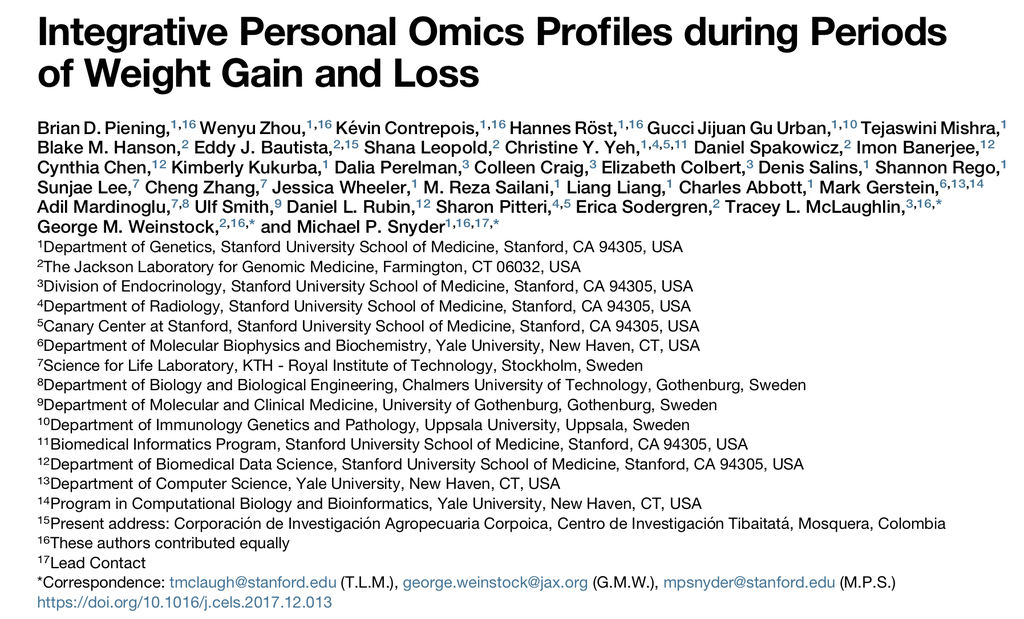

## n = 80, n_vars_ = 125,000

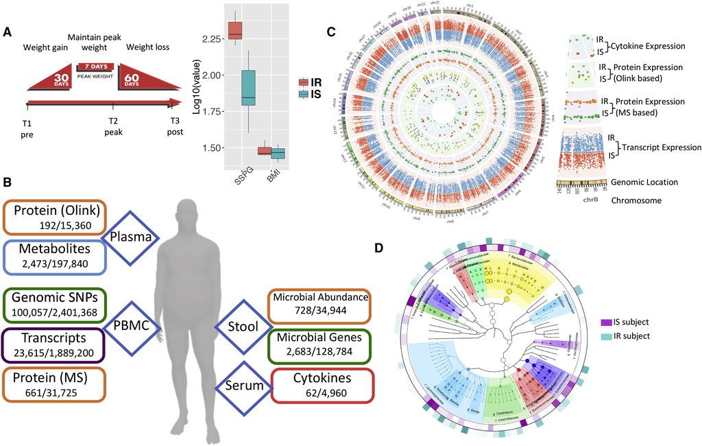

> *Our study revealed a number of important findings, including (1) modest weight gain in overweight humans was associated with the activation of inflammatory signatures in the blood, induction of markers and pathways for cardiovascular disease, and significant changes to the microbiome; (2) many of these changes affected IR participants differently from metabolically healthy controls (e.g., microbiome and metabolome differences); (3) the **longitudinal nature of the designed perturbation results in statistical power increases** that are equivalent to orders-of-magnitude larger cross-sectional studies, an important consideration for the design of future large-scale (and costly) multi-omics studies.*